# Random Forest Regression Modeling

Predicting Flood Damage of Northwest Florida Counties

Meagan Russell & Alexis Bjornstad

2026-01-01

## Introduction

Why:

- Flooding is a frequent and costly hazard in Northwest Florida
- Damage varies widely across flood events
- Understanding what drives this variability can help improve planning and mitigation efforts

Research Focus and Goal:

- This study examines flood events across 16 counties in Northwest Florida
- Uses historical data on flood events, rainfall, and county characteristics
- The goal is to explore whether these factors can help explain flood damage

## Key Questions

### What drives flood damage?

- Can rainfall patterns improve prediction?
- Do county-level characteristics matter?

### How can Machine Learning help?

- Can Random Forest be used to predict flood damage?
- If so, what variables are the most useful?

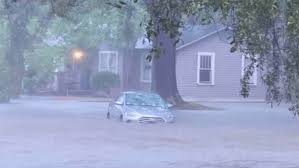

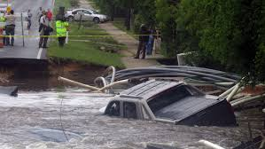

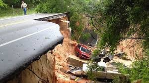

## Statiscial Method: Random Forest

Random forest is a flexible, buildable, and straightforward machine learning method. Random forest produces hundreds of decision trees and binary splitting to determine the best split per possible variable. Each tree is trained with a random parameter, and the splitting function is used for the selection of the more fitting observable variable.

[figure not shown]

Figure 1: Conceptual example of a random forest model showing multiple decision trees contributing to a final prediction.

## Features

### Assumptions

- Each tree makes its own decisions.
- Data points are chosen randomly to reduce mistakes.
- Sufficient data ensures the trees have unique patterns and variety.
- Combining the predictions from different trees leads to a more accurate final result.

### Advantages

- Easy to identify importance of features
- Multiple decision trees tend to cause little risk of overfitting (not too close to original training data)
- Very accurate due to multiple subgroups
- Less need for data management (pre-processing to perform random forest)

### Limitations

- Slower to acquire observations for best decision making
- Bound by the lowest and highest observations (no extrapolate)
- Difficult to interpret the decisions of ‘best features’ seen with trees

## Formula

Mean square error is used in random forest regression to determine the optimal splits during training and evaluate the model performance. The lower mean square error that is determined, the greater the model accuracy. The squared difference between actual and predicted values is squared (yᵢ − ŷᵢ)². 1 over the number of observations averages the total squared error. The summation symbol Σ represents the summation of the observed data points (Hodson et al. (2021)).

$$MSE = \frac{1}{n} \sum_{i=1}^{n} (y_i - \hat{y}_i)^2$$

## Study Area

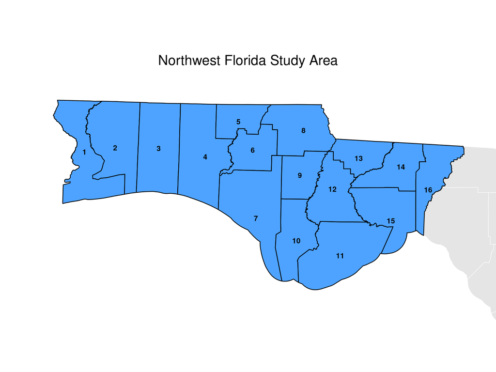

**Counties Included**

1. Escambia
2. Santa Rosa
3. Okaloosa
4. Walton
5. Holmes
6. Washington
7. Bay
8. Jackson
9. Calhoun
10. Gulf
11. Franklin
12. Liberty
13. Gadsden
14. Leon
15. Wakulla
16. Jefferson

# Analysis and Results

## Data Sources

Table 1: Variables Used in Random Forest Model

| Variable | Description | Unit | Source |
| --- | --- | --- | --- |
| County | County where the storm event occurred | County name | NOAA Storm Events Database |
| Date | Date of the storm event | Date | NOAA Storm Events Database |
| Flood Type | Classification of event (Flood or Flash Flood) | Category | NOAA Storm Events Database |
| Property Damage | Estimated property damage caused by the storm | USD ($) | NOAA Storm Events Database |
| Rainfall (1-day) | Total precipitation during the storm day | Inches | NOAA GHCN-Daily |
| Rainfall (3-day) | Total precipitation during storm day and previous two days | Inches | NOAA GHCN-Daily |
| Rainfall (7-day) | Total precipitation during storm day and previous six days | Inches | NOAA GHCN-Daily |
| Population | Total county population | Persons | U.S. Census Bureau ACS |
| Housing Units | Total number of housing units in the county | Count | U.S. Census Bureau ACS |
| Median Home Value | Median value of owner-occupied housing units | USD ($) | U.S. Census Bureau ACS |

## Data Visualization

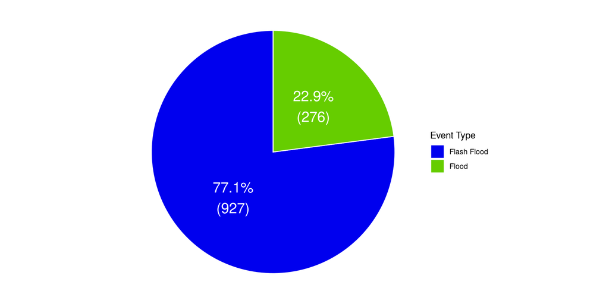

Figure 2: Flash Flood vs Flood Events (2000–Present)

## Flood Events Per County

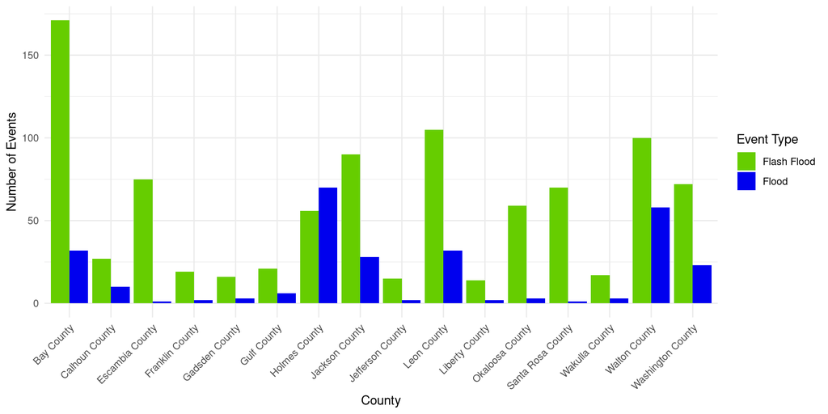

Figure 3: Flood and Flash Flood Events by County

## Flood Events Over Time

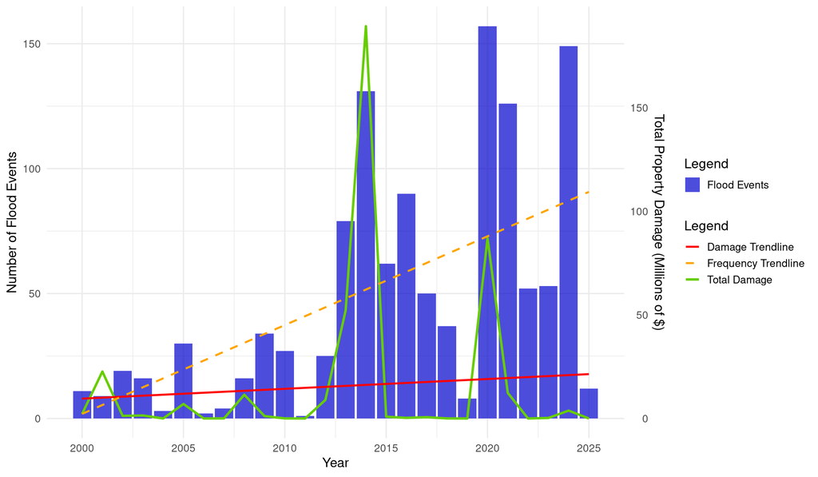

Figure 4: Flood Events and Property Damage Over Time

## Census Data

Table 2: Population, Housing Units, and Median Home Value by County

Population, Housing Units, and Median Home Value by County

Northwest Florida Counties (ACS 5-Year Estimates - 2024)

| County | Population | Housing Units | Median Home Value ($) |
| --- | --- | --- | --- |
| Escambia County | 325,923 | 149,217 | $257,200 |
| Leon County | 297,542 | 137,793 | $301,800 |
| Okaloosa County | 216,599 | 103,864 | $351,200 |
| Santa Rosa County | 198,472 | 80,002 | $329,800 |
| Bay County | 186,393 | 108,362 | $310,500 |
| Walton County | 82,948 | 61,272 | $425,100 |
| Jackson County | 48,250 | 20,145 | $120,800 |
| Gadsden County | 43,710 | 19,144 | $174,900 |
| Wakulla County | 35,387 | 14,599 | $258,300 |
| Washington County | 25,529 | 11,044 | $171,000 |
| Holmes County | 19,513 | 8,659 | $110,200 |
| Gulf County | 15,131 | 9,362 | $250,000 |
| Jefferson County | 15,091 | 6,886 | $232,600 |
| Calhoun County | 13,492 | 5,683 | $145,300 |
| Franklin County | 12,553 | 8,562 | $273,300 |
| Liberty County | 7,687 | 3,238 | $127,300 |

## Rainfall

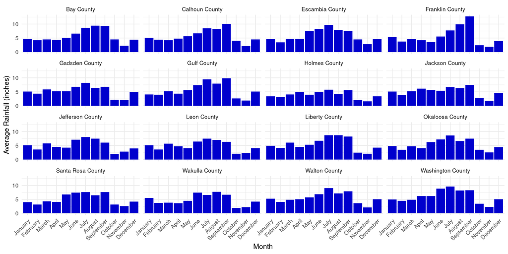

Figure 5: Average Monthly Rainfall by County

## Average Flood Events

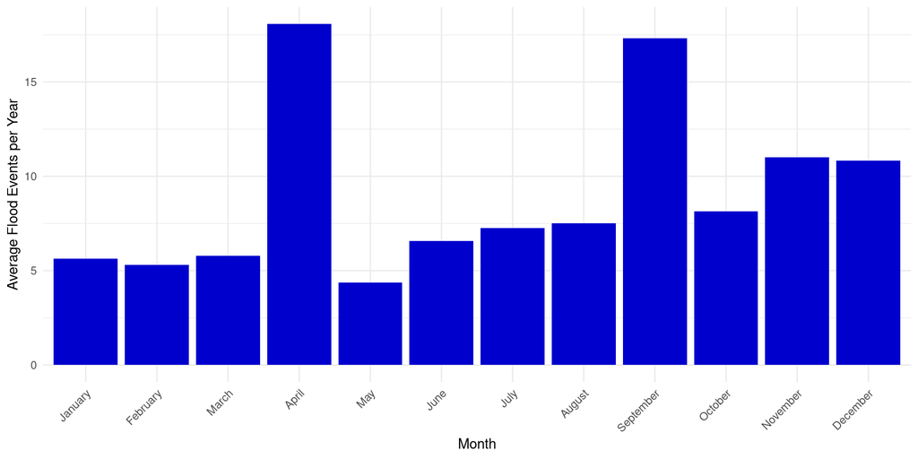

Figure 6: Average Number of Flood Events per Month

## Model Explanation

- Data was split using a 70/30 split.
- Model 1 used 1-day, 3-day, and 7-day prior rainfall, population, housing units, and median home value to predict total damage.
- Later models tested whether removing zero-damage events improved performance.
- Model 4 simplified the predictor set to 1-day prior rainfall, population, housing units, and median home value.
- The goal was to see whether a simpler model could better predict total flood damage.

## Model Performance Comparison

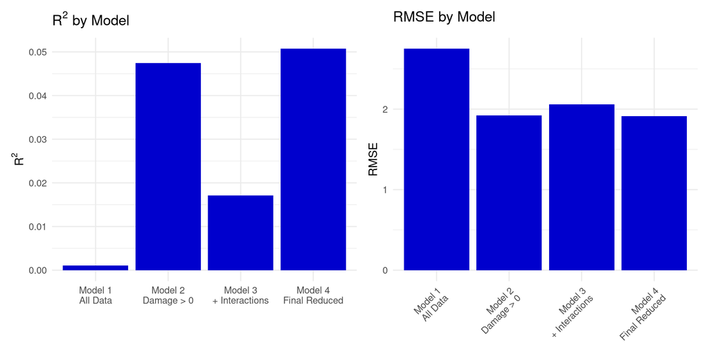

Figure 7: Random Forest Model Performance Comparison

## Predicted vs. Actual Flood Damage

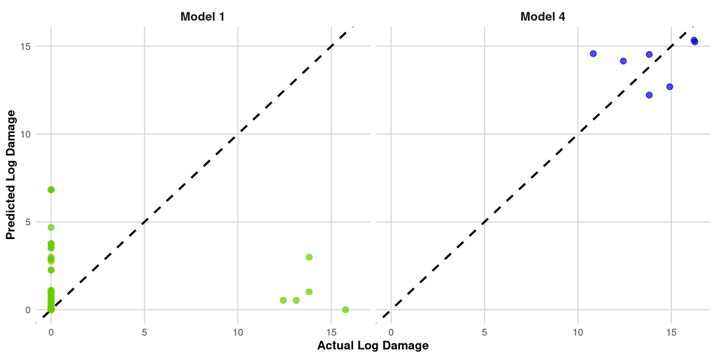

Figure 8: Predicted vs Actual Flood Damage for Model 1 and Model 4

## Top Five Counties

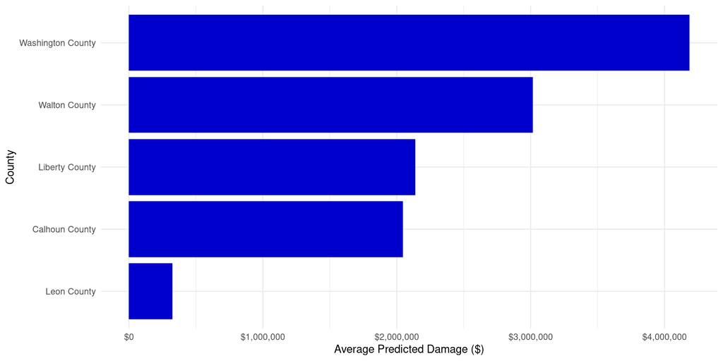

Figure 9: Average Predicted Flood Damage by County

## Discussion

- Random forest showed limited ability to predict flood damage (low R²)
- Flood damage likely influenced by missing variables
- Prior studies show elevation, slope, and proximity to rivers/streams are key factors
- Limitations: limited variables; flooding influenced by geophysical factors
- Future: additional variables needed to improve prediction

## Conclusion

- Random forest showed **limited ability** to predict flood damage
- Best model:
  - 1-day rainfall + population + housing + home value
  - excluded zero-damage events
- Improvements:
  - reduced noise
  - better actual vs predicted values
- Highest damage counties:
  - Washington, Walton, Liberty, Calhoun, Leon

## References

Akshay, S. et al. (2021). Predicting flood severity using machine learning and hybrid models. *International Journal of Disaster Risk Reduction*.

Bilskie, M. V., Hagen, S. C., Medeiros, S. C., & Passeri, D. L. (2014). Dynamics of sea level rise and coastal flooding on a changing landscape. *Geophysical Research Letters*, *41*(3), 927–934. https://doi.org/10.1002/2013GL058759

Chang, S., Wilkho, R. S., Gharaibeh, N., Sansom, G., Meyer, M., Olivera, F., & Zou, L. (2023). Environmental, climatic, and situational factors influencing the probability of fatality or injury occurrence in flash flooding: A rare event logistic regression predictive model. *Natural Hazards*, *116*(3), 3957–3978. https://doi.org/10.1007/s11069-023-05845-x

Chen, W., Li, Y., Xue, W., Shahabi, H., Li, S., Hong, H., Wang, X., Bian, H., Zhang, S., Pradhan, B., & Ahmad, B. (2020). Modeling flood susceptibility using data-driven approaches of naïve bayes tree, alternating decision tree, and random forest methods. *Science of The Total Environment*, *701*, 134979. https://doi.org/10.1016/j.scitotenv.2019.134979

Chen, Z., Wu, Q., Han, S., Zhang, J., Yang, P., & Liu, X. (2022). A study on geological structure prediction based on random forest method. *Artificial Intelligence in Geosciences*, *3*, 226–236. https://doi.org/10.1016/j.aiig.2023.01.004

Dey, H., Haque, M. M., Shao, W., VanDyke, M., & Hao, F. (2024). Simulating flood risk in tampa bay using a machine learning driven approach. *Npj Natural Hazards*, *1*, 40. https://doi.org/10.1038/s44304-024-00045-4

Diakakis, M., Boufidis, N., Salanova Grau, J. M., Andreadakis, E., & Stamos, I. (2020). A systematic assessment of the effects of extreme flash floods on transportation infrastructure and circulation: The example of the 2017 mandra flood. *International Journal of Disaster Risk Reduction*, *47*, 101542. https://doi.org/10.1016/j.ijdrr.2020.101542

Dutta, P., Paul, S., & Kumar, A. (2023). Comparative analysis of various supervised machine learning techniques for diagnosis of COVID-19. In *Machine learning for healthcare applications*. Elsevier. https://doi.org/10.1016/B978-0-323-85172-5.00020-4

Gensini, V. A., Converse, C., Ashley, W. S., & Taszarek, M. (2021). Machine learning classification of significant tornadoes and hail in the united states using ERA5 proximity soundings. *Weather and Forecasting*, *36*(6), 2143–2160.

Haddouchi, M., & Berrado, A. (2019). *A survey of methods and tools used for interpreting random forest*. 1–6. https://doi.org/10.1109/ICSSD47982.2019.9002770

Halsnæs, K., Larsen, M. A. D., Sunding, T. P., & Dømgaard, M. L. (2023). The value of advanced flood models, damage costs and land use data in cost-effective climate change adaptation. *Climate Services*, *32*, 100424. https://doi.org/10.1016/j.cliser.2023.100424

Hodson, T. O., Over, T. M., & Foks, S. S. (2021). Mean squared error, deconstructed. *Journal of Advances in Earth Systems Modeling*, *13*(12), e2021MS002681. https://doi.org/10.1029/2021MS002681

Intergovernmental Panel on Climate Change. (2021). Weather and climate extreme events in a changing climate. In V. Masson-Delmotte, P. Zhai, A. Pirani, S. L. Connors, C. Péan, S. Berger, N. Caud, Y. Chen, L. Goldfarb, M. I. Gomis, M. Huang, K. Leitzell, E. Lonnoy, J. B. R. Matthews, T. K. Maycock, T. Waterfield, O. Yelekçi, R. Yu, & B. Zhou (Eds.), *Climate change 2021: The physical science basis*. Cambridge University Press.

Javadinejad, S. (2022). Causes and consequences of floods: Flash floods, urban floods, river floods, and coastal floods. *Resources, Environment and Information Engineering*, *4*(1), 156–166. https://doi.org/10.25082/REIE.2022.01.002

Lecce, S. A. (2000). Spatial variations in the timing of annual floods in the southeastern united states. *Journal of Hydrology*, *235*(3-4), 151–169. https://doi.org/10.1016/S0022-1694(00)00273-0

Morss, R. E., Ahijevych, D., Fossell, K. R., Kowaleski, A. M., & Davis, C. A. (2024). Predictability of hurricane storm surge: An ensemble forecasting approach using global atmospheric model data. *Water*, *16*(11), 1523. https://doi.org/10.3390/w16111523

National Oceanic and Atmospheric Administration. (2024). *Storm events database*. https://www.ncdc.noaa.gov/stormevents/.

Rigatti, S. J. (2017). Random forest. *Journal of Insurance Medicine*, *47*(1), 31–39. https://doi.org/10.17849/insm-47-01-31-39.1

Sadkou, M. et al. (2024). A review of flash-floods management: From hydrological modeling to crisis management. *Journal of Flood Risk Management*. https://doi.org/10.1111/jfr3.12951

Sadkou, S., Artigue, G., Fréalle, N., Ayral, P.-A., Pistre, S., Sauvagnargues, S., & Johannet, A. (2024). A review of flash-floods management: From hydrological modeling to crisis management. *Journal of Flood Risk Management*, *17*(3), e12999. https://doi.org/10.1111/jfr3.12999

Saharia, M., Kirstetter, P.-E., Vergara, H., Gourley, J. J., Hong, Y., & Giroud, M. (2017). Mapping flash flood severity in the united states. *Journal of Hydrometeorology*, *18*(2), 397–411. https://doi.org/10.1175/JHM-D-16-0082.1

Salman, H. A., Kalakech, A., & Steiti, A. (2024). Random forest algorithm overview. *Babylonian Journal of Machine Learning*, *2024*, 69–79.

Schoppa, L., Disse, M., & Bachmair, S. (2020). Evaluating the performance of random forest for large-scale flood discharge simulation. *Journal of Hydrology*, *590*, 125531. https://doi.org/10.1016/j.jhydrol.2020.125531

Speiser, J. L., Miller, M. E., Tooze, J., & Ip, E. (2019). A comparison of random forest variable selection methods for classification prediction modeling. *Expert Systems with Applications*, *134*, 93–101. https://doi.org/10.1016/j.eswa.2019.05.028

Tan, X. Z., Li, Y., Wu, X. X., Dai, C., Zhang, X. L., & Cai, Y. P. (2024). Identification of the key driving factors of flash flood based on different feature selection techniques coupled with random forest method. *Journal of Hydrology: Regional Studies*, *51*, 101624. https://doi.org/10.1016/j.ejrh.2023.101624

U.S. Census Bureau. (2024). *American community survey 5-year estimates*. https://data.census.gov

Wahba, M., Essam, R., El-Rawy, M., Al-Arifi, N., Abdalla, F., & Elsadek, W. M. (2024). Forecasting of flash flood susceptibility mapping using random forest regression model and geographic information systems. *Heliyon*, *10*(13), e33982. https://doi.org/10.1016/j.heliyon.2024.e33982

Wang, Z., Lai, C., Chen, X., Yang, B., Zhao, S., & Bai, X. (2015). Flood hazard risk assessment model based on random forest. *Journal of Hydrology*, *527*, 1130–1141. https://doi.org/10.1016/j.jhydrol.2015.06.008

Zhu, Z., & Zhang, Y. (2022). Flood disaster risk assessment based on random forest algorithm. *Neural Computing and Applications*, *34*, 3443–3455. https://doi.org/10.1007/s00521-021-05757-6